# Wine Quality Analysis by Faraz Mirza

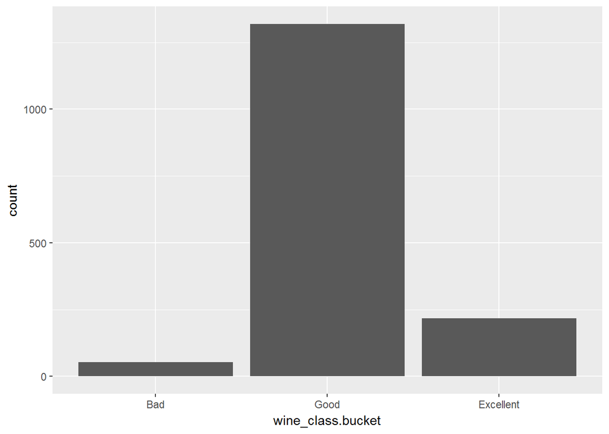

Now, that we’ve categorized wines, let’s find out which attributes differentiates a bad wine from an excellent wine. Let’s go with Alcohol percentage first.

```
##        X          fixed.acidity    volatile.acidity  citric.acid
##  Min.   :   8.0   Min.   : 4.900   Min.   :0.1200   Min.   :0.0000
##  1st Qu.: 482.0   1st Qu.: 7.400   1st Qu.:0.3000   1st Qu.:0.3000
##  Median : 939.0   Median : 8.700   Median :0.3700   Median :0.4000
##  Mean   : 831.7   Mean   : 8.847   Mean   :0.4055   Mean   :0.3765
##  3rd Qu.:1089.0   3rd Qu.:10.100   3rd Qu.:0.4900   3rd Qu.:0.4900
##  Max.   :1585.0   Max.   :15.600   Max.   :0.9150   Max.   :0.7600
##  residual.sugar    chlorides       free.sulfur.dioxide
##  Min.   :1.200   Min.   :0.01200   Min.   : 3.00
##  1st Qu.:2.000   1st Qu.:0.06200   1st Qu.: 6.00
##  Median :2.300   Median :0.07300   Median :11.00
##  Mean   :2.709   Mean   :0.07591   Mean   :13.98
##  3rd Qu.:2.700   3rd Qu.:0.08500   3rd Qu.:18.00
##  Max.   :8.900   Max.   :0.35800   Max.   :54.00
##  total.sulfur.dioxide    density             pH          sulphates
##  Min.   :  7.00       Min.   :0.9906   Min.   :2.880   Min.   :0.3900
##  1st Qu.: 17.00       1st Qu.:0.9947   1st Qu.:3.200   1st Qu.:0.6500
##  Median : 27.00       Median :0.9957   Median :3.270   Median :0.7400
##  Mean   : 34.89       Mean   :0.9960   Mean   :3.289   Mean   :0.7435
##  3rd Qu.: 43.00       3rd Qu.:0.9973   3rd Qu.:3.380   3rd Qu.:0.8200
##  Max.   :289.00       Max.   :1.0032   Max.   :3.780   Max.   :1.3600
##     alcohol         quality      wine_class.bucket
##  Min.   : 9.20   Min.   :7.000   Bad      :  0
##  1st Qu.:10.80   1st Qu.:7.000   Good     :  0
##  Median :11.60   Median :7.000   Excellent:217
##  Mean   :11.52   Mean   :7.083
##  3rd Qu.:12.20   3rd Qu.:7.000
##  Max.   :14.00   Max.   :8.000
```

```
##        X          fixed.acidity    volatile.acidity  citric.acid
##  Min.   :  19.0   Min.   : 4.600   Min.   :0.2300   Min.   :0.0000
##  1st Qu.: 435.0   1st Qu.: 6.800   1st Qu.:0.5650   1st Qu.:0.0200
##  Median : 834.0   Median : 7.500   Median :0.6800   Median :0.0800
##  Mean   : 837.7   Mean   : 7.871   Mean   :0.7242   Mean   :0.1737
##  3rd Qu.:1285.5   3rd Qu.: 8.400   3rd Qu.:0.8825   3rd Qu.:0.2700
##  Max.   :1522.0   Max.   :12.500   Max.   :1.5800   Max.   :1.0000
##  residual.sugar     chlorides       free.sulfur.dioxide
##  Min.   : 1.200   Min.   :0.04500   Min.   : 3.00
##  1st Qu.: 1.900   1st Qu.:0.06850   1st Qu.: 5.00
##  Median : 2.100   Median :0.08000   Median : 9.00
##  Mean   : 2.685   Mean   :0.09573   Mean   :12.06
##  3rd Qu.: 2.950   3rd Qu.:0.09450   3rd Qu.:15.50
##  Max.   :12.900   Max.   :0.61000   Max.   :41.00
##  total.sulfur.dioxide    density             pH          sulphates
##  Min.   :  7.00       Min.   :0.9934   Min.   :2.740   Min.   :0.3300
##  1st Qu.: 13.50       1st Qu.:0.9957   1st Qu.:3.300   1st Qu.:0.4950
##  Median : 26.00       Median :0.9966   Median :3.380   Median :0.5600
##  Mean   : 34.44       Mean   :0.9967   Mean   :3.384   Mean   :0.5922
##  3rd Qu.: 48.00       3rd Qu.:0.9977   3rd Qu.:3.500   3rd Qu.:0.6000
##  Max.   :119.00       Max.   :1.0010   Max.   :3.900   Max.   :2.0000
##     alcohol         quality      wine_class.bucket
##  Min.   : 8.40   Min.   :3.000   Bad      :53
##  1st Qu.: 9.60   1st Qu.:4.000   Good     : 0
##  Median :10.00   Median :4.000   Excellent: 0
##  Mean   :10.22   Mean   :3.841   NA's     :10
##  3rd Qu.:11.00   3rd Qu.:4.000
##  Max.   :13.10   Max.   :4.000
```

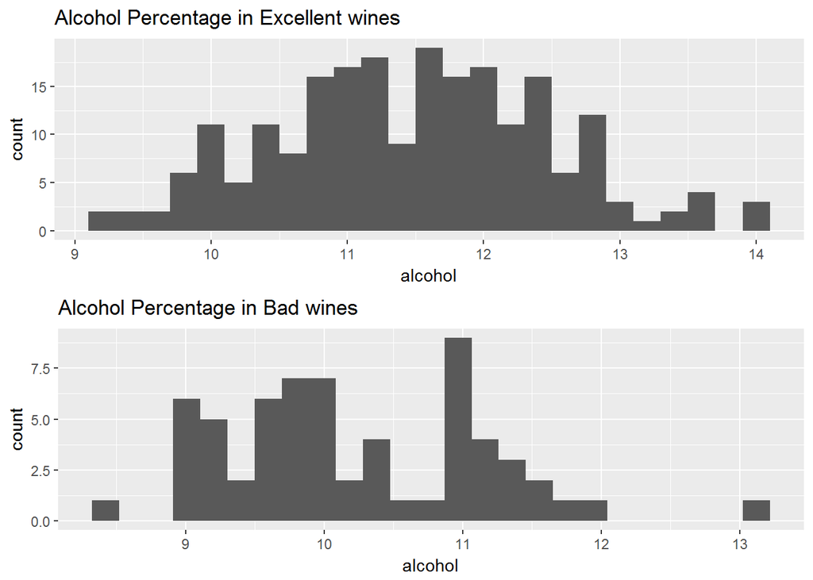

Well majority of excellent wines have alcohol percentage of between 10.6 - 12.5 while bad wines have between 9 - 11. I’ll analyse this further in the next section of Bivariate Analysis, with more detailed visualizations for better understanding.

# Univariate Analysis

### What is the structure of your dataset?

There are 1599 Red wines along with their 13 Atrributes.

### What is/are the main feature(s) of interest in your dataset?

Each feature/Attribute shows some kind of pattern but we cannot call any one of them significant to others. For example most Excellent wines have higher percentage of Alcohol on average but there exist many with lower percentages as well, Which means a lot of factors are playing a significant role in making a wine better than the rest.

### What other features in the dataset do you think will help support your investigation into your feature(s) of interest?

After visualising many features with different angles, I think Volatile Acidity of the wine, Amount of Sulphate and Citric Acid added will help me support my invesigation.

# Bivariate Plots Section

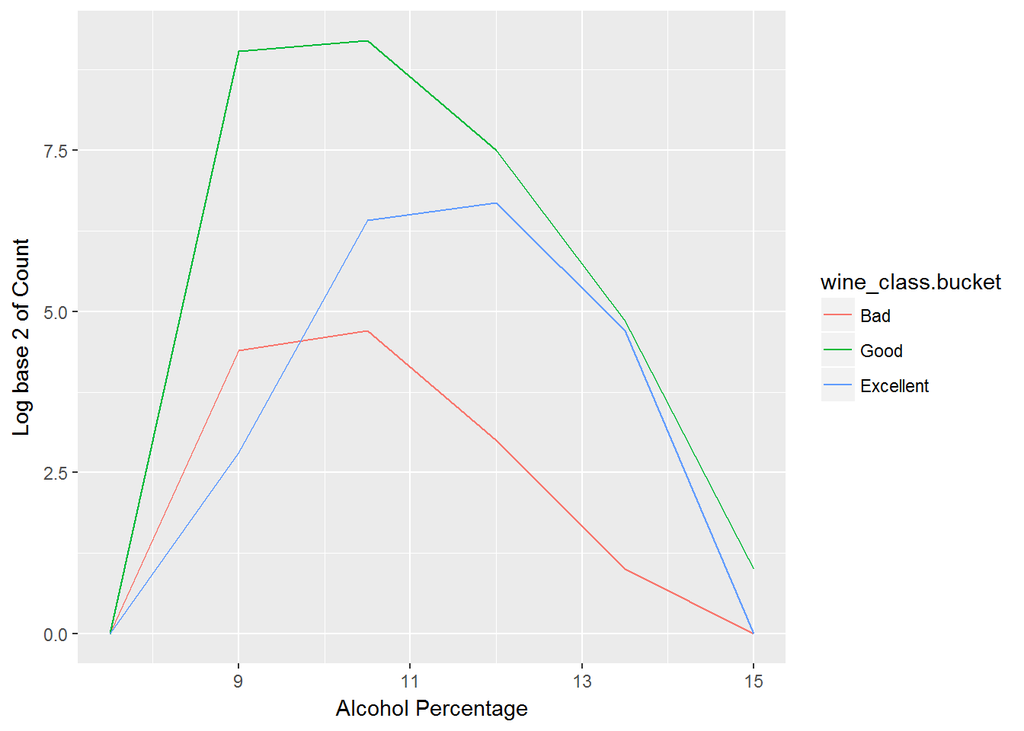

This Frquency Polygon shows all three categories of wines based on their Alcohol Percentage. We can see that Excellent wines have a bit left skewed polygon while the other two have right skewed polygons. Although the data is transformed but since the numbers vary by a large margin, it might confuse some people as the size of polygons differ. Let’s try another visualization.

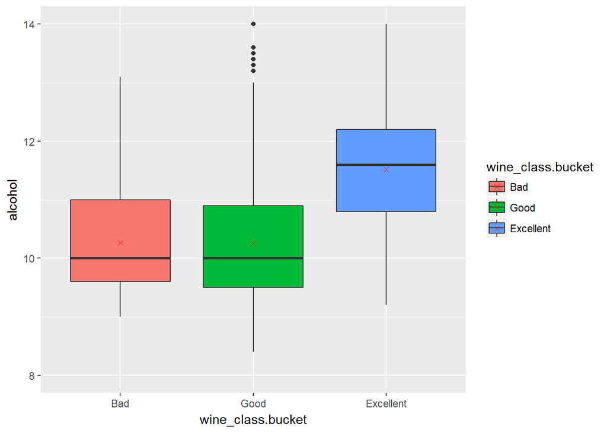

I guess box plot gives us a better representation of how Excellent wines have higher alcohol percentage than others. More the alcohol, the faster you get tipsy and better the score. Obviously there are a lot of other factors involved since good and bad wines have the same median alcohol percentage. There exist some bad wines who have high percentages like Excellent wines. What’s causing them to score bad? Let’s check out other attributes like Volatile Acidity, Sulphates and Citric Acid.

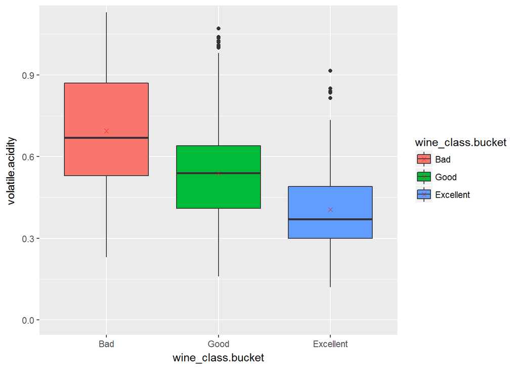

```
##
##  Pearson's product-moment correlation
##
## data:  volatile.acidity and quality
## t = -16.954, df = 1597, p-value < 2.2e-16
## alternative hypothesis: true correlation is not equal to 0
## 95 percent confidence interval:
##  -0.4313210 -0.3482032
## sample estimates:
##        cor
## -0.3905578
```

We can see a pattern here. Bad wines have, on average, high volatile acidity and it gets lower as the wines get better.

A high acidity wine gives a weird smell and tastes dry unless there’s a high amount of sugar in wine to counter it.

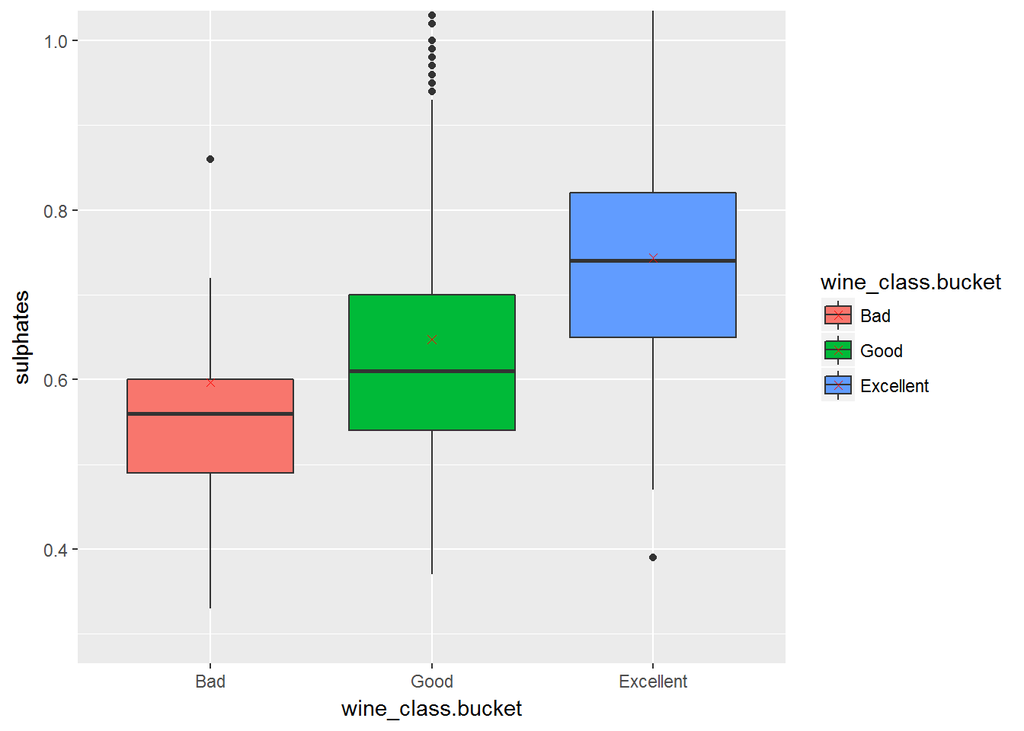

```
##
##  Pearson's product-moment correlation
##
## data:  sulphates and quality
## t = 10.38, df = 1597, p-value < 2.2e-16
## alternative hypothesis: true correlation is not equal to 0
## 95 percent confidence interval:
##  0.2049011 0.2967610
## sample estimates:
##       cor
## 0.2513971
```

Sulphate is a wine additive that is responible for producing sulphur dioxide which prevents microbial growth and the oxidation of wine keeping the wine edible for long period of time. However large amounts can ruin the wine’s taste and smell. It seems though that less than 0.6g/dm3 of amount is not good enough.

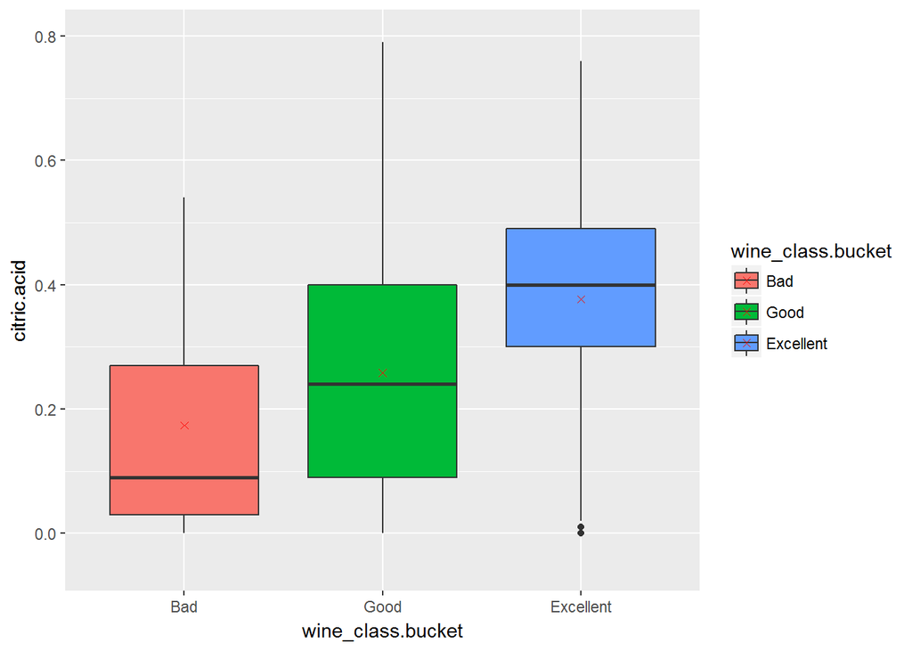

```
##
##  Pearson's product-moment correlation
##
## data:  citric.acid and quality
## t = 9.2875, df = 1597, p-value < 2.2e-16
## alternative hypothesis: true correlation is not equal to 0
## 95 percent confidence interval:
##  0.1793415 0.2723711
## sample estimates:
##       cor
## 0.2263725
```

Citric acid brings freshness and flavor to wine. That’s not my opinion. Experts say so and so does the data.

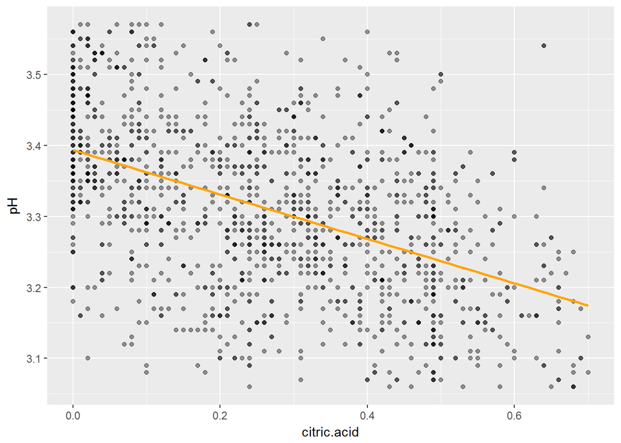

The scatter plot with support of the conditional mean, which is being represented by the orange line shows an inverse relationship between pH and citric acid. As the quantity of citric acid is increasing, the pH level is decreasing(More Acidic).

```
##
##  Pearson's product-moment correlation
##
## data:  citric.acid and pH
## t = -25.767, df = 1597, p-value < 2.2e-16
## alternative hypothesis: true correlation is not equal to 0
## 95 percent confidence interval:
##  -0.5756337 -0.5063336
## sample estimates:
##        cor
## -0.5419041
```

The Correlation coefficient between pH and Citric Acid is -0.542. So we can clearly assume that citric acid plays a vital role effecting the pH of wine.

```
## # A tibble: 6 x 4
##   quality citric_acid_mean citric_acid_median     n
##     <int>            <dbl>              <dbl> <int>
## 1       3        0.1710000              0.035    10
## 2       4        0.1741509              0.090    53
## 3       5        0.2436858              0.230   681
## 4       6        0.2738245              0.260   638
## 5       7        0.3751759              0.400   199
## 6       8        0.3911111              0.420    18
```

Mean citric acid increases as the quality increases.

```
## # A tibble: 6 x 4
##   quality sulphates_mean sulphates_median     n
##     <int>          <dbl>            <dbl> <int>
## 1       3      0.5700000            0.545    10
## 2       4      0.5964151            0.560    53
## 3       5      0.6209692            0.580   681
## 4       6      0.6753292            0.640   638
## 5       7      0.7412563            0.740   199
## 6       8      0.7677778            0.740    18
```

Mean Sulphates increases as the quality increases.

```
## # A tibble: 6 x 4
##   quality volatile_acidity_mean volatile_acidity_median     n
##     <int>                 <dbl>                   <dbl> <int>
## 1       3             0.8845000                   0.845    10
## 2       4             0.6939623                   0.670    53
## 3       5             0.5770411                   0.580   681
## 4       6             0.4974843                   0.490   638
## 5       7             0.4039196                   0.370   199
## 6       8             0.4233333                   0.370    18
```

Mean volatile acidity decreases as the quality increases.

```
## # A tibble: 6 x 4
##    alcohol density_mean density_median     n
##      <dbl>        <dbl>          <dbl> <int>
## 1 13.40000     6.933333          7.000     3
## 2 13.50000     1.500000          1.500     1
## 3 13.56667     1.820000          1.820     1
## 4 13.60000     1.722500          1.695     4
## 5 14.00000     1.825714          1.600     7
## 6 14.90000     7.600000          7.600     1
```

Reason I brought up density now as a feature is because at first, I thought since all the wines have almost the same density(between 0.99 - 1), there’s no point analyzing it. But I did some research on red wine and found out that density of red wine actually means a lot. Density in wine is a weighted average of water, ethanol and sugar. It’s mostly water with slight variations of ethanol and sugar that’s why all the values lie near 1 which is the density of water. I deducted 0.99 from all the values and multiplied it with 1000 to increase the scale and closely look at the small differences.

Unlike Quality, Alcohol does not contain discrete values. So, a plot visualisation would better to check if there is a relation between density and alcohol.

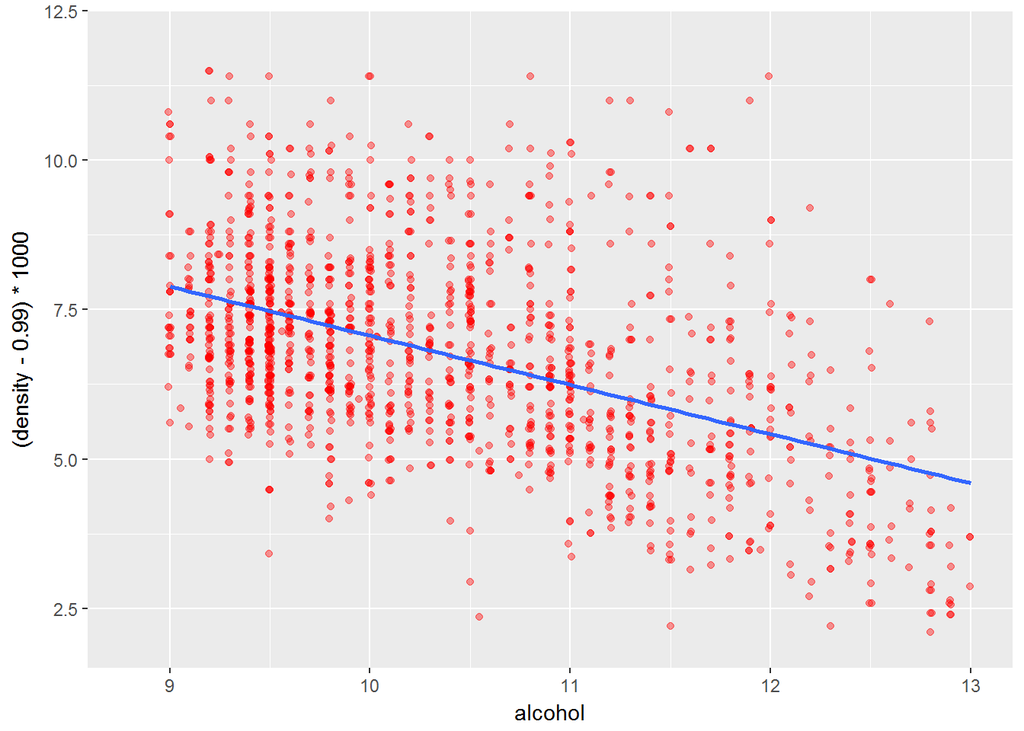

```
##
##  Pearson's product-moment correlation
##
## data:  alcohol and density
## t = -22.838, df = 1597, p-value < 2.2e-16
## alternative hypothesis: true correlation is not equal to 0
## 95 percent confidence interval:
##  -0.5322547 -0.4583061
## sample estimates:
##        cor
## -0.4961798
```

The Pearson’s Correlation Coeffient is approximately -0.5 which is considered a good correlation.

# Bivariate Analysis

### How did the feature(s) of interest vary with other features in the dataset?

We analyzed that there’s a considerable difference in Alcohol, Citric acid, Volatile Acidity and Sulphates in Excellent and Bad wines which led us to the conclusion that the qualiy of wine can change by variation in their amounts.

### Did you observe any interesting relationships between the other features (not the main feature(s) of interest)?

Other than these features, we found out some other interesting features and their relationships as well. First one is between Citric acid and pH level. Apparently, Citric Acid lowers down the pH level of wine turning it more acidic. The second one was between Alcohol and Density. Alcohol lowers down the density of wine as it is thiner than water naturally.

# Multivariate Plots Section

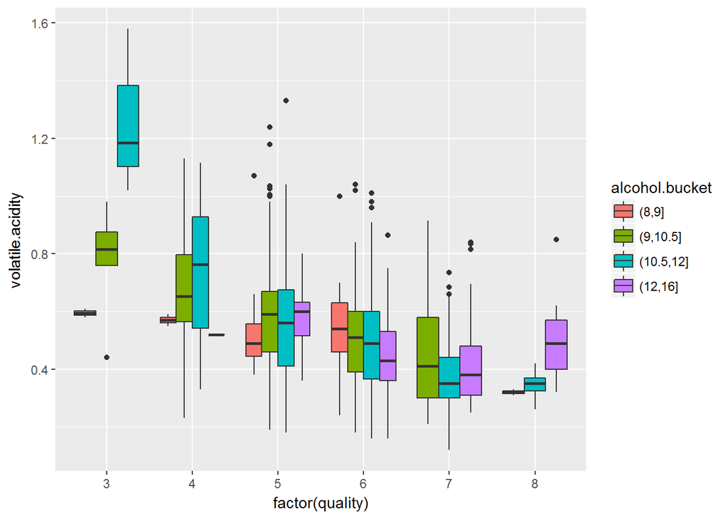

So we’ll start our Multivariable analysis with the strongest features, Volatile Acidity and Alcohol according to each wine quality. Wines with high quality mostly consist of high alcohol(10.5-16) while bad quality wines mostly contains low alcohol content(8-12). The Volatile Acidity is high in bad wines and gradually decreses as the quality increases.

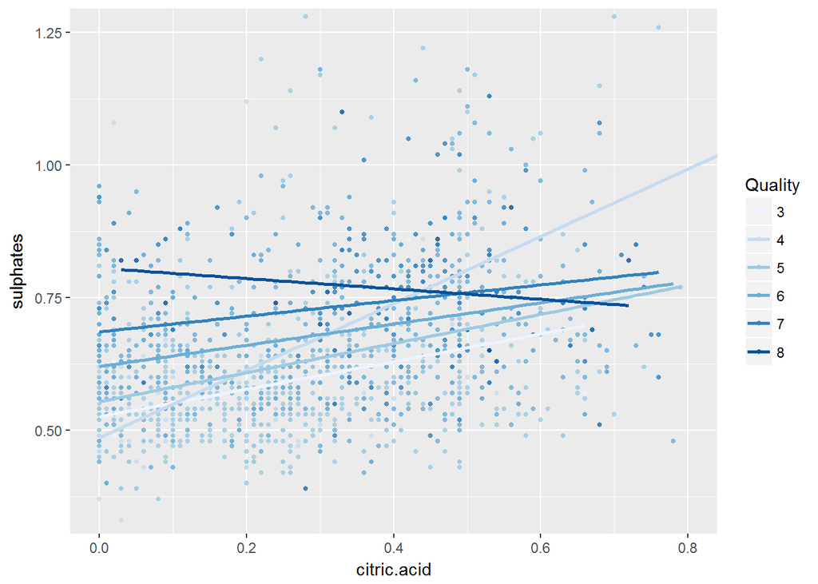

Scatter plot of the the next 2 properties that has the greatest effect on wine quality, Sulphates and Citric Acid. The amount of Citric acid and Sulphates tend to be higher in high quality wines.

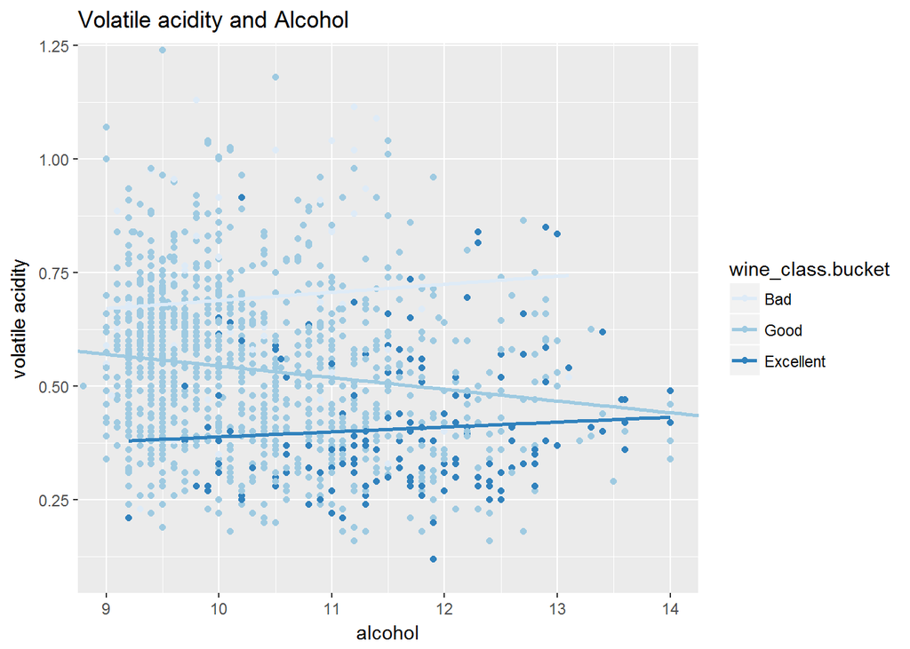

This is another plot containing the strongest 2 features showing along with wine classes as shaded colour points. We can clearly see that excellent wines lie in low volatile acidity range and high alcohol percentage range.

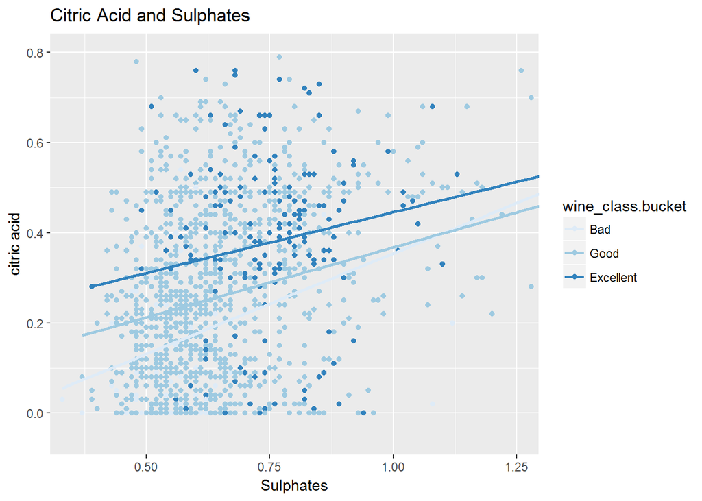

Although the count of bad wines is low but we can still see that they mostly lie in lower side of Sulphates and Citric Acid.

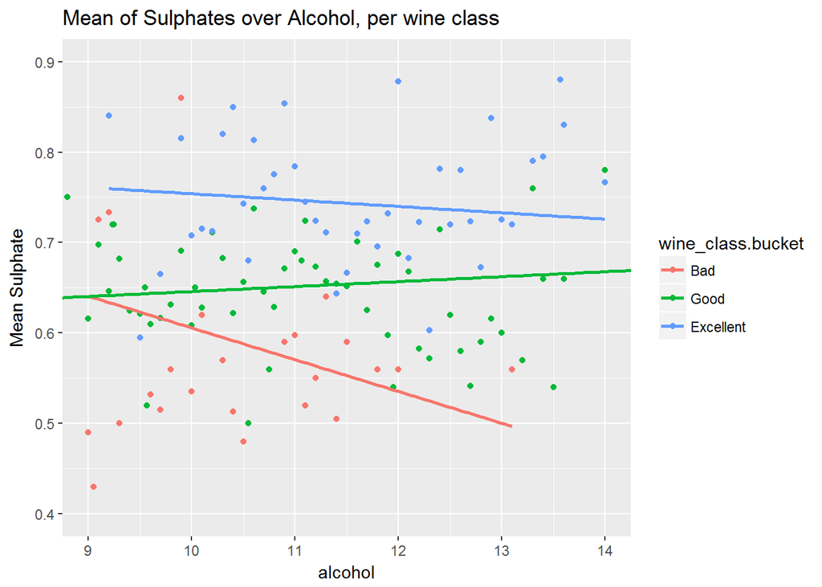

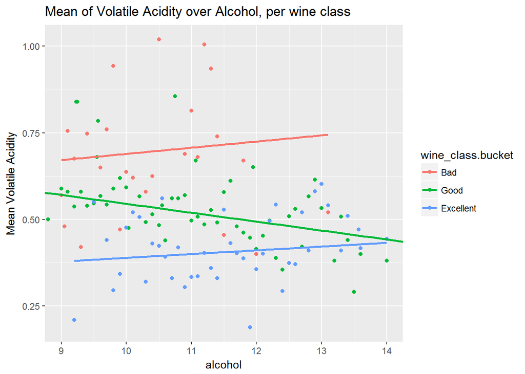

```
##
## Calls:
## m1: lm(formula = quality ~ volatile.acidity, data = wine)
## m2: lm(formula = quality ~ volatile.acidity + alcohol, data = wine)
## m3: lm(formula = quality ~ volatile.acidity + alcohol + sulphates,
##     data = wine)
## m4: lm(formula = quality ~ volatile.acidity + alcohol + sulphates +
##     citric.acid, data = wine)
##
## ================================================================
##                        m1         m2         m3         m4
## ----------------------------------------------------------------
##   (Intercept)       6.566***   3.095***   2.611***   2.646***
##                    (0.058)    (0.184)    (0.196)    (0.201)
##   volatile.acidity -1.761***  -1.384***  -1.221***  -1.265***
##                    (0.104)    (0.095)    (0.097)    (0.113)
##   alcohol                      0.314***   0.309***   0.309***
##                               (0.016)    (0.016)    (0.016)
##   sulphates                               0.679***   0.696***
##                                          (0.101)    (0.103)
##   citric.acid                                       -0.079
##                                                     (0.104)
## ----------------------------------------------------------------
##   R-squared             0.2        0.3        0.3        0.3
##   adj. R-squared        0.2        0.3        0.3        0.3
##   sigma                 0.7        0.7        0.7        0.7
##   F                   287.4      370.4      268.9      201.8
##   p                     0.0        0.0        0.0        0.0
##   Log-likelihood    -1794.3    -1621.8    -1599.4    -1599.1
##   Deviance            883.2      711.8      692.1      691.9
##   AIC                3594.6     3251.6     3208.8     3210.2
##   BIC                3610.8     3273.1     3235.7     3242.4
##   N                  1599       1599       1599       1599
## ================================================================
```

The model can be described as:

wine_quality = 2.646 + 0.309xalcohol - 1.265xvolatile.acidity + 0.696xsulphates - 0.079xcitric.acid

```r
thisWine = data.frame(volatile.acidity = 0.3, alcohol = 13,
                         sulphates = 0.8, citric.acid=0.8)
modelEstimate = predict(m4, newdata = thisWine,
                        interval="prediction", level = .8)

round(modelEstimate)
```

```
##   fit lwr upr
## 1   7   6   8
```

# Multivariate Analysis

### Were there any interesting or surprising interactions between features?

Each combination of features were grouped together along with which wine quality class they belong due to whivh I was able to observe multiple patterns such as Volatile Acidity of Excellent wines were comparatively lower than others. The amount of Citric Acid and Sulphates added in Excellent wines were higher than those that were bad.

# Linear Multivariable Model

I made a Linaer Model based on 4 main features: Alcohol, Volatile Acidity, Sulphates and Citric Acid. It is not a perfect model but a fairly good one. I ran it on some arbitrary values that should make an Excellent wine. It predicted a quality score of 7 with an upper bound of 8.

# Final Plots and Summary

### Plot One

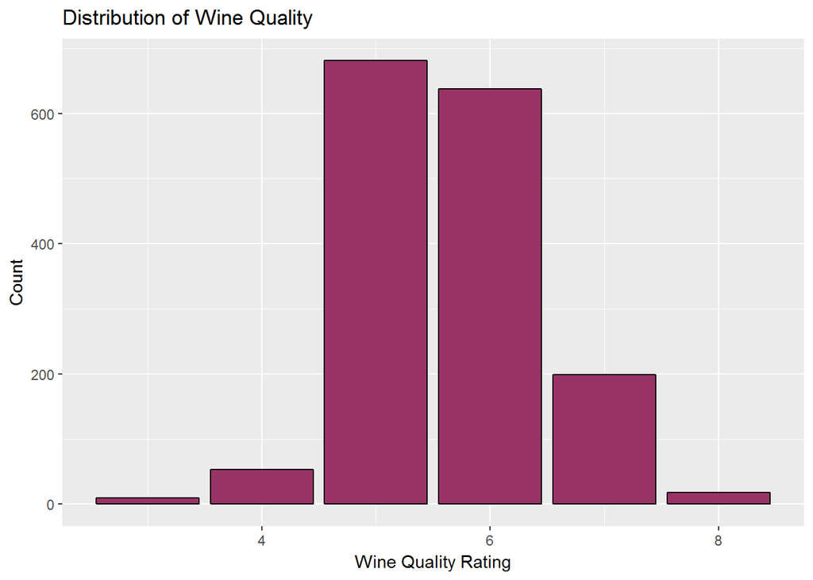

### Description One

Plot one shows the distribution of wine quality. Note that dataset is unbalanced. There are many Good quality wines(grade 5, 6), but much fewer count of Bad(grade 3,4) and Excellent (grade 7, 8) quality wine.

### Plot Two

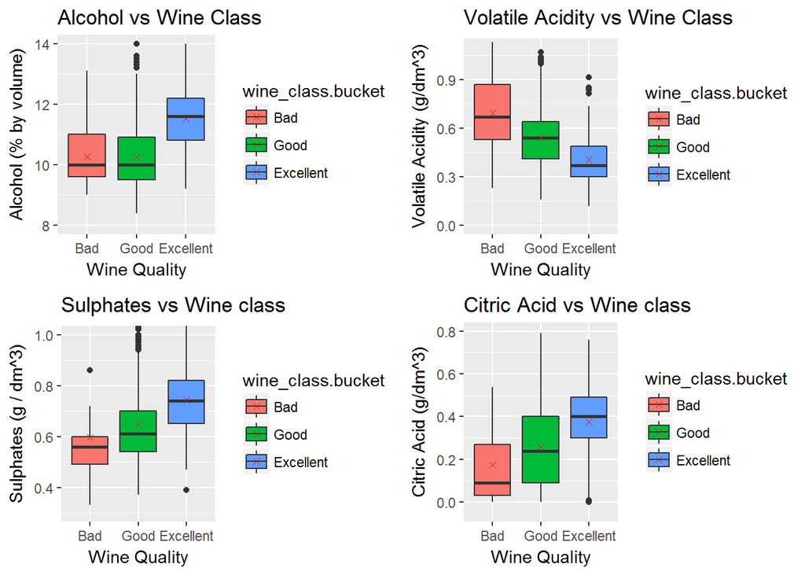

### Description Two

The 4 features that have the highest correlation coefficient are alcohol, volatile acidity, sulphates and citric acid. The wine quality are grouped to Bad (3,4) Good (5.6) and Excellent (7,8). Excellent quality wine have high alcohol level however, there is no significant different between Good and Bad quality wine. Volatile acidity decrease as wine quality increases. Sulphate and critic acid increase as wine quality increase.

### Plot Three

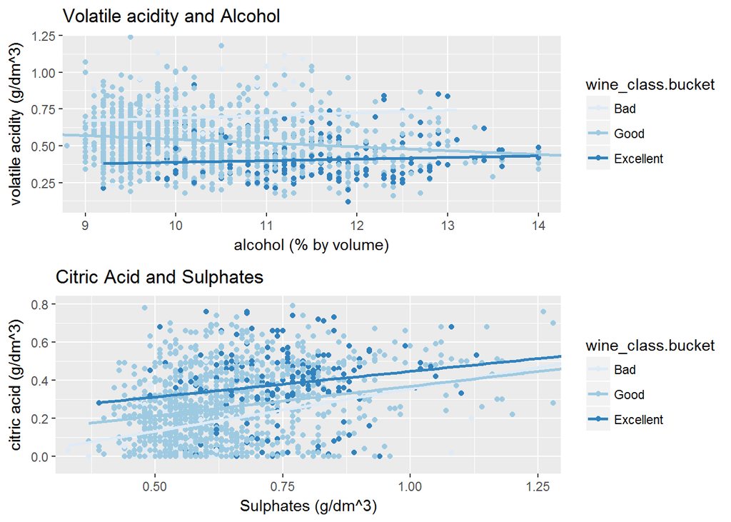

### Description Three

The 4 features are also represented in the scatter plot. 2 features are plotted at a time with color indicate wine quality. Similar trend as the last figure can be observed. In general, high quality wine tend to have higher alcohol and lower volatile acidity content. They also tend to have higher sulphate and higher critic acid content.

# Reflection

I have worked on a lot bigger datasets(vertically and horizontally). However, having few features to explore didn’t made it easier. There was no significant feature that have a high impact on the quality. It was more complex than it looked. After analysing various plots and correlations, I chose the 4 strongest features: Alcohol, Volatile Acidity, Sulphates and Citric Acid. In between, I came up with a few surprising and interesting relationships that weren’t exactly corelated with wine quality but still, it was fun to know. The Citric Acid was highly corelated with pH level of wines and Alcohol was to density. This is because Alcohol has a lower density than water and therefore, it changes density of the wine as well.

Another difficulty I faced was during the multivariable Analysis. There wasn’t a single categorial feature making the analysis process difficult to proceed further. Luckily, I felt the need to create one at the start of the project and I came up with the idea of categorizing wines into Bad, Good and Excellent based on their quality scores.

In the end, a linear model of 4 features was created to predict wine quality. However, wine quality is a complex object. The linear model is an overly simplified model. Good wine is more than perfect combination of different chemical components.

Future improvement can be made if more data can be collected of wines with low quality score as well as high quality scores. The dataset is highly unbalanced. If the data set has more features especially some categorial features, the quality of analysis can be improved. We can be more certain about whether there is a significant correlation between a chemical component and the wine quality and create a better prediction model.